# DSC 478 - Assignement 4 - Shuyang Ding - 1856131

# 1. PCA for Reduced Dimensionality in Clustering

a. Load in the image data matrix (with rows as images and columns as features). Also load in the numeric class labels from the segmentation class file. Using your favorite method (e.g., sklearn's min-max scaler), perform min-max normalization on the data matrix so that each feature is scaled to [0,1] range.

```python
import pandas as pd
import numpy as np
import pylab as pl
```

```python
# Import image matrix dataset
image_matrix = pd.read_csv('C:/Users/shuya/OneDrive/Documents/Depaul/DSC478/Assignment 4/segmentation_data/segmentation_data.txt', delimiter= ",", header = None)
image_names = pd.read_csv('C:/Users/shuya/OneDrive/Documents/Depaul/DSC478/Assignment 4/segmentation_data/segmentation_names.txt',delimiter='\t',header=None)
```

```python
image_matrix.head(5)
```

|  | 0 | 1 | 2 | 3 | 4 | 5 | 6 | 7 | 8 | 9 | 10 | 11 | 12 | 13 | 14 | 15 | 16 | 17 | 18 |
| --- | --- | --- | --- | --- | --- | --- | --- | --- | --- | --- | --- | --- | --- | --- | --- | --- | --- | --- | --- |
| 0 | 110.0 | 189.0 | 9 | 0.0 | 0.0 | 1.000000 | 0.666667 | 1.222222 | 1.186342 | 12.925926 | 10.888889 | 9.222222 | 18.666668 | -6.111111 | -11.111111 | 17.222221 | 18.666668 | 0.508139 | 1.910864 |
| 1 | 86.0 | 187.0 | 9 | 0.0 | 0.0 | 1.111111 | 0.720082 | 1.444444 | 0.750309 | 13.740741 | 11.666667 | 10.333334 | 19.222221 | -6.222222 | -10.222222 | 16.444445 | 19.222221 | 0.463329 | 1.941465 |
| 2 | 225.0 | 244.0 | 9 | 0.0 | 0.0 | 3.388889 | 2.195113 | 3.000000 | 1.520234 | 12.259259 | 10.333334 | 9.333334 | 17.111110 | -5.777778 | -8.777778 | 14.555555 | 17.111110 | 0.480149 | 1.987902 |
| 3 | 47.0 | 232.0 | 9 | 0.0 | 0.0 | 1.277778 | 1.254621 | 1.000000 | 0.894427 | 12.703704 | 11.000000 | 9.000000 | 18.111110 | -5.111111 | -11.111111 | 16.222221 | 18.111110 | 0.500966 | 1.875362 |
| 4 | 97.0 | 186.0 | 9 | 0.0 | 0.0 | 1.166667 | 0.691215 | 1.166667 | 1.005540 | 15.592592 | 13.888889 | 11.777778 | 21.111110 | -5.111111 | -11.444445 | 16.555555 | 21.111110 | 0.442661 | 1.863654 |

```python
image_names[0][0]
```

```
'REGION-CENTROID-COL'
```

```python
image_matrix.shape
```

```
(2100, 19)
```

```python
image_matrix_name = image_names[0].tolist()
image_matrix_name
```

```
['REGION-CENTROID-COL',
 'REGION-CENTROID-ROW',
 'REGION-PIXEL-COUNT',
 'SHORT-LINE-DENSITY-5',
 'SHORT-LINE-DENSITY-2',
 'VEDGE-MEAN',
 'VEDGE-SD',
 'HEDGE-MEAN',
 'HEDGE-SD',
 'INTENSITY-MEAN',
 'RAWRED-MEAN',
 'RAWBLUE-MEAN',
 'RAWGREEN-MEAN',
 'EXRED-MEAN',
 'EXBLUE-MEAN',
 'EXGREEN-MEAN',
 'VALUE-MEAN',
 'SATURATION-MEAN',
 'HUE-MEAN']
```

```python
image_matrix.columns = image_matrix_name
image_matrix.head(5)
```

|  | REGION-CENTROID-COL | REGION-CENTROID-ROW | REGION-PIXEL-COUNT | SHORT-LINE-DENSITY-5 | SHORT-LINE-DENSITY-2 | VEDGE-MEAN | VEDGE-SD | HEDGE-MEAN | HEDGE-SD | INTENSITY-MEAN | RAWRED-MEAN | RAWBLUE-MEAN | RAWGREEN-MEAN | EXRED-MEAN | EXBLUE-MEAN | EXGREEN-MEAN | VALUE-MEAN | SATURATION-MEAN | HUE-MEAN |
| --- | --- | --- | --- | --- | --- | --- | --- | --- | --- | --- | --- | --- | --- | --- | --- | --- | --- | --- | --- |
| 0 | 110.0 | 189.0 | 9 | 0.0 | 0.0 | 1.000000 | 0.666667 | 1.222222 | 1.186342 | 12.925926 | 10.888889 | 9.222222 | 18.666668 | -6.111111 | -11.111111 | 17.222221 | 18.666668 | 0.508139 | 1.910864 |
| 1 | 86.0 | 187.0 | 9 | 0.0 | 0.0 | 1.111111 | 0.720082 | 1.444444 | 0.750309 | 13.740741 | 11.666667 | 10.333334 | 19.222221 | -6.222222 | -10.222222 | 16.444445 | 19.222221 | 0.463329 | 1.941465 |
| 2 | 225.0 | 244.0 | 9 | 0.0 | 0.0 | 3.388889 | 2.195113 | 3.000000 | 1.520234 | 12.259259 | 10.333334 | 9.333334 | 17.111110 | -5.777778 | -8.777778 | 14.555555 | 17.111110 | 0.480149 | 1.987902 |
| 3 | 47.0 | 232.0 | 9 | 0.0 | 0.0 | 1.277778 | 1.254621 | 1.000000 | 0.894427 | 12.703704 | 11.000000 | 9.000000 | 18.111110 | -5.111111 | -11.111111 | 16.222221 | 18.111110 | 0.500966 | 1.875362 |
| 4 | 97.0 | 186.0 | 9 | 0.0 | 0.0 | 1.166667 | 0.691215 | 1.166667 | 1.005540 | 15.592592 | 13.888889 | 11.777778 | 21.111110 | -5.111111 | -11.444445 | 16.555555 | 21.111110 | 0.442661 | 1.863654 |

```python
#Import class label dataset
image_class = pd.read_csv('C:/Users/shuya/OneDrive/Documents/Depaul/DSC478/Assignment 4/segmentation_data/segmentation_classes.txt',delimiter='\t',header=None)
```

```python
image_class.columns = ['label', 'numeric label']
```

```python
image_class.head(5)
```

|  | label | numeric label |
| --- | --- | --- |
| 0 | GRASS | 0 |
| 1 | GRASS | 0 |
| 2 | GRASS | 0 |
| 3 | GRASS | 0 |
| 4 | GRASS | 0 |

```python
# Min-max normalization
from sklearn import preprocessing
min_max_scaler = preprocessing.MinMaxScaler().fit(image_matrix)
image_marix_norm = min_max_scaler.transform(image_matrix)
image_marix_norm
```

```
array([[0.43083004, 0.74166667, 0.        , ..., 0.12371135, 0.50813884,
        0.83184923],
       [0.33596838, 0.73333333, 0.        , ..., 0.12739322, 0.46332908,
        0.83698646],
       [0.88537549, 0.97083333, 0.        , ..., 0.11340205, 0.48014903,
        0.84478233],
       ...,
       [0.50197628, 0.625     , 0.        , ..., 0.07216495, 0.5409177 ,
        0.17591546],
       [0.58893281, 0.6125    , 0.        , ..., 0.08100147, 0.50308645,
        0.18478933],
       [0.48616601, 0.62916667, 0.        , ..., 0.09646539, 0.4799313 ,
        0.17037463]])
```

b. Using the Kmeans implementation in scikit-learn, perform clustering on the image data (use K = 7 in your clustering so that later we can compare the clusters to the 7 pre-assigned image classes). Print the cluster centroids (use some formatting so that they are visually understandable). To evaluate your clusters, first perform Silhouette analysis on the clusters (compute Silhouette values for all instances in the data, and then compute the overall mean Silhouette value; optionally, you can provide a visaulization of the Silhouettes). Next, compare your 7 clusters to the 7 pre-assigned classes by computing the Completeness and Homogeneity values of the generated clusters.

```python
# Perform clustering
from sklearn.cluster import KMeans
kMeans = KMeans(n_clusters = 7)
kMeans.fit(image_marix_norm)
```

```
KMeans(algorithm='auto', copy_x=True, init='k-means++', max_iter=300,
    n_clusters=7, n_init=10, n_jobs=None, precompute_distances='auto',
    random_state=None, tol=0.0001, verbose=0)
```

```python
#Cluster centroids
kMeans.cluster_centers_
pd.DataFrame(kMeans.cluster_centers_.T, index=image_matrix_name, columns=['Cluster 1', 'Cluster 2','Cluster 3','Cluster 4','Cluster 5',' Cluster 6','Cluster 7'])
```

|  | Cluster 1 | Cluster 2 | Cluster 3 | Cluster 4 | Cluster 5 | Cluster 6 | Cluster 7 |
| --- | --- | --- | --- | --- | --- | --- | --- |
| REGION-CENTROID-COL | 0.770674 | 0.535099 | 0.750696 | 0.256103 | 0.513994 | 0.302506 | 0.254169 |
| REGION-CENTROID-ROW | 0.425215 | 0.150167 | 0.534564 | 0.393468 | 0.808937 | 0.530862 | 0.459974 |
| REGION-PIXEL-COUNT | 0.000000 | 0.000000 | 0.000000 | 0.000000 | 0.000000 | 0.000000 | 0.000000 |
| SHORT-LINE-DENSITY-5 | 0.013978 | 0.027778 | 0.040000 | 0.074510 | 0.077441 | 0.052260 | 0.026256 |
| SHORT-LINE-DENSITY-2 | 0.022581 | 0.001667 | 0.038462 | 0.019118 | 0.005051 | 0.046610 | 0.013699 |
| VEDGE-MEAN | 0.040237 | 0.030228 | 0.114419 | 0.077343 | 0.054474 | 0.100817 | 0.037274 |
| VEDGE-SD | 0.002989 | 0.000543 | 0.019301 | 0.004100 | 0.001407 | 0.009420 | 0.002364 |
| HEDGE-MEAN | 0.023122 | 0.026766 | 0.109240 | 0.060574 | 0.046335 | 0.083972 | 0.027874 |
| HEDGE-SD | 0.002088 | 0.000587 | 0.017999 | 0.004967 | 0.001401 | 0.011043 | 0.002017 |
| INTENSITY-MEAN | 0.041138 | 0.823246 | 0.300955 | 0.148187 | 0.108790 | 0.400608 | 0.026013 |
| RAWRED-MEAN | 0.035005 | 0.779716 | 0.279908 | 0.138085 | 0.091403 | 0.370347 | 0.017925 |
| RAWBLUE-MEAN | 0.058340 | 0.894170 | 0.352738 | 0.185160 | 0.092414 | 0.472461 | 0.042306 |
| RAWGREEN-MEAN | 0.028766 | 0.788761 | 0.265920 | 0.118539 | 0.142676 | 0.353036 | 0.016504 |
| EXRED-MEAN | 0.778473 | 0.270665 | 0.592572 | 0.716906 | 0.679161 | 0.497146 | 0.769800 |
| EXBLUE-MEAN | 0.223939 | 0.666373 | 0.451124 | 0.344014 | 0.079002 | 0.570882 | 0.216011 |
| EXGREEN-MEAN | 0.486509 | 0.289386 | 0.309158 | 0.355458 | 0.821287 | 0.213054 | 0.508117 |
| VALUE-MEAN | 0.059295 | 0.894170 | 0.352822 | 0.185413 | 0.134901 | 0.472461 | 0.043295 |
| SATURATION-MEAN | 0.538181 | 0.211804 | 0.302342 | 0.411986 | 0.414491 | 0.302263 | 0.801687 |
| HUE-MEAN | 0.243969 | 0.125066 | 0.164764 | 0.201890 | 0.892333 | 0.163879 | 0.181153 |

```python
# Silhouette analysis
from sklearn import metrics
clusters = kMeans.predict(image_marix_norm)
silhouettes = metrics.silhouette_samples(image_marix_norm, clusters)
print(silhouettes[:20])
```

```
[0.57202831 0.56064636 0.46584172 0.49522097 0.57151852 0.56037254
 0.54213796 0.41254281 0.51968142 0.46733032 0.48661677 0.49108474
 0.58463969 0.56222519 0.37949564 0.53083575 0.54919193 0.42227935
 0.41618572 0.40389039]
```

```python
print('Overall mean Silhouette: ',silhouettes.mean())
```

```
Overall mean Silhouette:  0.332066475286672
```

```python
#plot Silhouette
def plot_silhouettes(data, clusters, metric='euclidean'):

    from matplotlib import cm
    from sklearn.metrics import silhouette_samples

    cluster_labels = np.unique(clusters)
    n_clusters = cluster_labels.shape[0]
    silhouette_vals = metrics.silhouette_samples(data, clusters, metric='euclidean')
    c_ax_lower, c_ax_upper = 0, 0
    cticks = []
    for i, k in enumerate(cluster_labels):
        c_silhouette_vals = silhouette_vals[clusters == k]
        c_silhouette_vals.sort()
        c_ax_upper += len(c_silhouette_vals)
        color = cm.jet(float(i) / n_clusters)
        pl.barh(range(c_ax_lower, c_ax_upper), c_silhouette_vals, height=1.0,
                      edgecolor='none', color=color)

        cticks.append((c_ax_lower + c_ax_upper) / 2)
        c_ax_lower += len(c_silhouette_vals)

    silhouette_avg = np.mean(silhouette_vals)
    pl.axvline(silhouette_avg, color="red", linestyle="--")

    pl.yticks(cticks, cluster_labels)
    pl.ylabel('Cluster')
    pl.xlabel('Silhouette coefficient')

    pl.tight_layout()
    #pl.savefig('images/11_04.png', dpi=300)
    pl.show()

    return
```

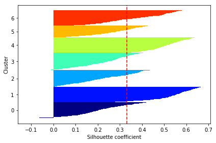

```python
plot_silhouettes(image_marix_norm, clusters)
```

```python
# Compute completeness and Homogeneity
from sklearn.metrics import completeness_score, homogeneity_score
completeness = completeness_score(image_class['numeric label'], kMeans.labels_)
homogeneity = homogeneity_score(image_class['numeric label'], kMeans.labels_)

print('Completeness Score: ', completeness)
print('Homogeneity Score: ', homogeneity )
```

```
Completeness Score:  0.613187012485301
Homogeneity Score:  0.6115021163370862
```

c. Perform PCA on the normalized image data matrix. You may use the linear algebra package in Numpy or the Decomposition module in scikit-learn (the latter is much more efficient). Analyze the principal components to determine the number, r, of PCs needed to capture at least 95% of variance in the data. Provide a plot of PC variances. Then use these r components as features to transform the data into a reduced dimension space.

```python
#PCA Using scikit-learn
from sklearn import decomposition
pca = decomposition.PCA(n_components = 10)
dtrans = pca.fit(image_marix_norm).transform(image_marix_norm)
```

```python
print (dtrans)
```

```
[[-0.6891  0.533   0.2461 ... -0.0049  0.     -0.0036]
 [-0.6669  0.5107  0.338  ... -0.0195  0.0007 -0.0056]
 [-0.712   0.7709 -0.1558 ...  0.0495 -0.0479  0.0441]
 ...
 [-0.5077 -0.1294 -0.0822 ...  0.0257 -0.0084 -0.0759]
 [-0.4791 -0.0863 -0.1587 ...  0.0345 -0.033  -0.0496]
 [-0.4423 -0.1062 -0.0471 ...  0.1252 -0.0463 -0.1071]]
```

```python
np.set_printoptions(precision = 4, suppress = True)
variance = pca.explained_variance_ratio_
print(variance)
```

```
[0.6071 0.132  0.1012 0.0454 0.0355 0.0199 0.0189 0.0162 0.0107 0.0071]
```

```python
variance.sum()
```

```
0.9939823945149533
```

The first 7 components are capturing at least 95% variance in the data.

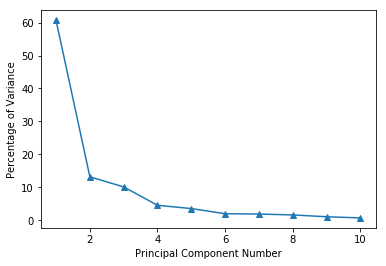

```python
# Plot of PC variance
import matplotlib.pyplot as plt
%matplotlib inline

fig = plt.figure()
ax = fig.add_subplot(111)
ax.plot(range(1, 11),variance*100, marker='^')
plt.xlabel('Principal Component Number')
plt.ylabel('Percentage of Variance')
plt.show()
```

```python
# Transform data into a reduced dimension space - Using 7 components
pca = decomposition.PCA(n_components=7)
DTtrans = pca.fit(image_marix_norm).transform(image_marix_norm)
np.set_printoptions(precision=2,suppress=True)
print (DTtrans)
```

```
[[-0.69  0.53  0.25 ... -0.08  0.05 -0.05]
 [-0.67  0.51  0.34 ... -0.04  0.06 -0.04]
 [-0.71  0.77 -0.16 ... -0.17  0.04 -0.06]
 ...
 [-0.51 -0.13 -0.08 ... -0.03 -0.03 -0.11]
 [-0.48 -0.09 -0.16 ...  0.   -0.   -0.09]
 [-0.44 -0.11 -0.05 ...  0.02 -0.21  0.15]]
```

d. Perform Kmeans again, but this time on the lower dimensional transformed data. Then compare Silhouette values as well as completeness and Homogeneity values of the new clusters. Compare these results with those obtained on the full data in part b.

```python
# Performing Kmeans on lower dimensional data
kmeans_dt = KMeans(n_clusters=7)
kmeans_dt.fit(DTtrans)
```

```
KMeans(algorithm='auto', copy_x=True, init='k-means++', max_iter=300,
    n_clusters=7, n_init=10, n_jobs=None, precompute_distances='auto',
    random_state=None, tol=0.0001, verbose=0)
```

```python
kmeans_dt.labels_
```

```
array([3, 3, 3, ..., 6, 6, 5])
```

```python
kmeans_dt.cluster_centers_
pd.DataFrame(kmeans_dt.cluster_centers_.T, index=['PC 1','PC 2','PC 3','PC 4', 'PC 5', 'PC 6', 'PC 7'], columns=['Cluster 1', 'Cluster 2','Cluster 3','Cluster 4','Cluster 5',' Cluster 6','Cluster 7'])
```

|  | Cluster 1 | Cluster 2 | Cluster 3 | Cluster 4 | Cluster 5 | Cluster 6 | Cluster 7 |
| --- | --- | --- | --- | --- | --- | --- | --- |
| PC 1 | 0.177392 | 0.435888 | -0.603705 | -0.619268 | 1.414527 | -0.207423 | -0.510409 |
| PC 2 | 0.043820 | -0.105299 | -0.355503 | 0.640250 | 0.087223 | -0.246366 | -0.064687 |
| PC 3 | -0.264946 | 0.165257 | 0.109197 | 0.195829 | 0.036765 | 0.152532 | -0.336363 |
| PC 4 | 0.184546 | 0.233499 | -0.129799 | -0.086856 | -0.173195 | 0.056618 | -0.065008 |
| PC 5 | 0.026771 | -0.045031 | -0.130911 | -0.067760 | -0.029922 | 0.130311 | 0.078962 |
| PC 6 | 0.024409 | -0.007272 | -0.021603 | 0.008866 | -0.008973 | -0.005704 | 0.006227 |
| PC 7 | 0.003417 | 0.015049 | -0.043882 | 0.038372 | -0.021573 | 0.033045 | -0.026326 |

```python
clusters = kmeans_dt.predict(DTtrans)
```

```python
completeness_dt = completeness_score(image_class['numeric label'], kmeans_dt.labels_)
homogeneity_dt = homogeneity_score(image_class['numeric label'], kmeans_dt.labels_)
silhouettes_dt = metrics.silhouette_samples(DTtrans, clusters)
print('Completeness Score: ',completeness)
print('Homogeneity Score: ',homogeneity)
print('Silhouette Value: ', homogeneity)
```

```
Completeness Score:  0.613187012485301
Homogeneity Score:  0.6115021163370862
Silhouette Value:  0.6115021163370862
```

# 2. Item-Based Joke Recommendation

a. Load in the joke ratings data and the joke text data into appropriate data structures. Use the "recommend" function to provide top 5 joke recommendations for at least 2 users. Use both standard item-based collaborative filtering (based on the rating prediction function "standEst") and the SVD-based version of the item-based CF (using "svdEst" as the prediction engine) to generate these recommendations for the two users and note the differences. You should show the text of the recommended jokes as well as the predicted ratings for each.

```python
from numpy import *
from numpy import linalg as la
```

```python
def euclidSim(inA,inB):
    return 1.0/(1.0 + la.norm(inA - inB))

def pearsonSim(inA,inB):
    if len(inA) < 3 : return 1.0
    return 0.5+0.5*corrcoef(inA, inB, rowvar = 0)[0][1]

def cosineSim(inA,inB):
    num = float(inA.T*inB)
    denom = la.norm(inA)*la.norm(inB)
    return 0.5+0.5*(num/denom)
```

```python
def standEst(dataMat, user, simMeas, item):
    n = shape(dataMat)[1]
    simTotal = 0.0; ratSimTotal = 0.0
    for j in range(n):
        userRating = dataMat[user,j]
        if userRating == 0:
            continue
        overLap = nonzero(logical_and(dataMat[:,item]>0, dataMat[:,j]>0))[0]
        if len(overLap) == 0:
            similarity = 0
        else:
            similarity = simMeas(dataMat[overLap,item], dataMat[overLap,j])
        #print('the %d and %d similarity is: %f' % (item, j, similarity))
        simTotal += similarity
        ratSimTotal += similarity * userRating
    if simTotal == 0: return 0
    else: return ratSimTotal/simTotal
```

```python
def svdEst(dataMat, user, simMeas, item):
    n = shape(dataMat)[1]
    simTotal = 0.0; ratSimTotal = 0.0
    data=mat(dataMat)
    U,Sigma,VT = la.svd(data)
    Sig4 = mat(eye(4)*Sigma[:4]) #arrange Sig4 into a diagonal matrix
    xformedItems = data.T * U[:,:4] * Sig4.I  #create transformed items
    for j in range(n):
        userRating = data[user,j]
        if userRating == 0 or j==item: continue
        similarity = simMeas(xformedItems[item,:].T, xformedItems[j,:].T)
        #print('the %d and %d similarity is: %f' % (item, j, similarity))
        simTotal += similarity
        ratSimTotal += similarity * userRating
    if simTotal == 0: return 0
    else: return ratSimTotal/simTotal
```

```python
def recommend(dataMat, user, N=3, simMeas=cosineSim, estMethod=standEst):
    ratedItems = nonzero(dataMat[user,:].A)[1]
    itemScores = []
    for item in ratedItems:
        estimatedScore = estMethod(dataMat, user, simMeas, item)
        itemScores.append((item, estimatedScore))
    return sorted(itemScores, key=lambda jj: jj[1], reverse=True)[:N]
```

```python
def load_jokes(file):
    jokes = np.genfromtxt(file, delimiter=',', dtype=str)
    jokes = np.array(jokes[:,1])
    return jokes
```

```python
def get_joke_text(jokes, id):
    return jokes[id]
```

```python
# Import joke rating data and joke text
joke = load_jokes('C:/Users/shuya/OneDrive/Documents/Depaul/DSC478/Assignment 4/jokes/jokes.csv')
joke.shape
```

```
(100,)
```

```python
rating = np.genfromtxt('C:/Users/shuya/OneDrive/Documents/Depaul/DSC478/Assignment 4/jokes/modified_jester_data.csv',delimiter=',')
rating
```

```
array([[ 3.18, 19.79,  1.34, ...,  0.  ,  0.  ,  0.  ],
       [15.08, 10.71, 17.36, ..., 11.34,  6.68, 12.07],
       [ 0.  ,  0.  ,  0.  , ...,  0.  ,  0.  ,  0.  ],
       ...,
       [16.58, 16.63, 15.85, ...,  0.  ,  0.  ,  0.  ],
       [ 3.67,  4.45,  3.67, ...,  3.77,  3.77,  3.28],
       [ 9.88, 11.73,  9.16, ...,  0.  ,  0.  ,  0.  ]])
```

```python
rating_data = np.mat(rating)
rating_data
```

```
matrix([[ 3.18, 19.79,  1.34, ...,  0.  ,  0.  ,  0.  ],
        [15.08, 10.71, 17.36, ..., 11.34,  6.68, 12.07],
        [ 0.  ,  0.  ,  0.  , ...,  0.  ,  0.  ,  0.  ],
        ...,
        [16.58, 16.63, 15.85, ...,  0.  ,  0.  ,  0.  ],
        [ 3.67,  4.45,  3.67, ...,  3.77,  3.77,  3.28],
        [ 9.88, 11.73,  9.16, ...,  0.  ,  0.  ,  0.  ]])
```

```python
# Recommendations - standEst
for u in range(5,8):
    recommendations_s = recommend(rating_data, 5, N=5, simMeas=cosineSim, estMethod=standEst)
    print("Recommended Items for User", u, ":\n")
    for i, p in recommendations_s:
        print("Predicted Rating: ", p, "\n","Joke:\n",get_joke_text(joke, i),"\n" )
        print("------------------------------------------------------------------")
```

```
Recommended Items for User 5 :

Predicted Rating:  6.116392726692702
 Joke:
 Q:  What did the blind person say when given some matzah?A:  Who the hell wrote this?

------------------------------------------------------------------
Predicted Rating:  6.11613351655954
 Joke:
 Q. Did you hear about the dyslexic devil worshipper? A. He sold his soul to Santa.

------------------------------------------------------------------
Predicted Rating:  6.1147382747422405
 Joke:
 A dog walks into Western Union and asks the clerk to send a telegram. He fills out a form on which he writes down the telegram he wishes to send: "Bow wow wow Bow wow wow."The clerk says "You can add another 'Bow wow' for the same price."The dog responded "Now wouldn't that sound a little silly?"

------------------------------------------------------------------
Predicted Rating:  6.113260782149544
 Joke:
 A neutron walks into a bar and orders a drink."How much do I owe you?" the neutron asks.The bartender replies "for you no charge."

------------------------------------------------------------------
Predicted Rating:  6.112945473763903
 Joke:
 A guy goes into confession and says to the priest "Father I'm 80 years old widower with 11 grandchildren. Last night I met two beautiful flight attendants. They took me home and I made love to both of them. Twice."The priest said: "Well my son when was the last time you were in confession?" "Never …

------------------------------------------------------------------
Recommended Items for User 6 :

Predicted Rating:  6.116392726692702
 Joke:
 Q:  What did the blind person say when given some matzah?A:  Who the hell wrote this?

------------------------------------------------------------------
Predicted Rating:  6.11613351655954
 Joke:
 Q. Did you hear about the dyslexic devil worshipper? A. He sold his soul to Santa.

------------------------------------------------------------------
Predicted Rating:  6.1147382747422405
```

[output cut: 26 more lines]

```
Predicted Rating:  6.1147382747422405
 Joke:
 A dog walks into Western Union and asks the clerk to send a telegram. He fills out a form on which he writes down the telegram he wishes to send: "Bow wow wow Bow wow wow."The clerk says "You can add another 'Bow wow' for the same price."The dog responded "Now wouldn't that sound a little silly?"

------------------------------------------------------------------
Predicted Rating:  6.113260782149544
 Joke:
 A neutron walks into a bar and orders a drink."How much do I owe you?" the neutron asks.The bartender replies "for you no charge."

------------------------------------------------------------------
Predicted Rating:  6.112945473763903
 Joke:
 A guy goes into confession and says to the priest "Father I'm 80 years old widower with 11 grandchildren. Last night I met two beautiful flight attendants. They took me home and I made love to both of them. Twice."The priest said: "Well my son when was the last time you were in confession?" "Never …

------------------------------------------------------------------
```

```python
# Recommendations - svdEst
for v in range(5,8):
    recommendations_svd = recommend(rating_data, v, N=5, simMeas=cosineSim, estMethod=svdEst)
    print("Recommended Items for User", v, ":\n")
    for i, p in recommendations_svd:
        print("Predicted Rating: ", p, "\n","Joke:\n",get_joke_text(joke, i),"\n" )
        print("------------------------------------------------------------------")
```

```
Recommended Items for User 5 :

Predicted Rating:  6.372099258882093
 Joke:
 How many feminists does it take to screw in a light bulb?That's not funny.

------------------------------------------------------------------
Predicted Rating:  6.368747820460636
 Joke:
 Q. What is orange and sounds like a parrot?  A. A carrot.

------------------------------------------------------------------
Predicted Rating:  6.3412138232021285
 Joke:
 They asked the Japanese visitor if they have elections in his country.  "Every Morning" he answers.

------------------------------------------------------------------
Predicted Rating:  6.325587567547088
 Joke:
 The graduate with a Science degree asks "Why does it work?"The graduate with an Engineering degree asks "How does it work?"The graduate with an Accounting degree Asks "How much will it cost?" The graduate with a  Liberal Arts degree asks "Do you want fries with  that?"

------------------------------------------------------------------
Predicted Rating:  6.316047751076502
 Joke:
 A lawyer opened the door of his BMW when suddenly a car came along and hit the door ripping it off completely.  When the police arrived at the scene the lawyer was complaining bitterly about the damage to his precious BMW.  "Officer look what they've done to my Beeeeemer!!!" he whined.  "You lawyer…

------------------------------------------------------------------
Recommended Items for User 6 :

Predicted Rating:  16.034252493444157
 Joke:
 They asked the Japanese visitor if they have elections in his country.  "Every Morning" he answers.

------------------------------------------------------------------
Predicted Rating:  15.962325935737242
 Joke:
 Q. What is orange and sounds like a parrot?  A. A carrot.

------------------------------------------------------------------
Predicted Rating:  15.941094694143647
```

[output cut: 26 more lines]

```
Predicted Rating:  9.176287895268016
 Joke:
 Q. What is orange and sounds like a parrot?  A. A carrot.

------------------------------------------------------------------
Predicted Rating:  9.077420370111229
 Joke:
 Q:  What did the blind person say when given some matzah?A:  Who the hell wrote this?

------------------------------------------------------------------
Predicted Rating:  9.072025637643263
 Joke:
 Q. Did you hear about the dyslexic devil worshipper? A. He sold his soul to Santa.

------------------------------------------------------------------
```

b. Complete the definition for the function "test". This function iterates over all users and for each performs evaluation (by calling the provided "cross_validate_user" function), and returns the error information necessary to compute Mean Absolute Error (MAE). Use this function to perform evaluation (with 20% test-ratio for each user) comparing MAE results using the rating prediction function "standEst" with results using the "svdEst" prediction function. [Note: See comments provided in the module for hints on accomplishing these tasks.]

```python
def cross_validate_user(dataMat, user, test_ratio, estMethod=standEst, simMeas=pearsonSim):
    number_of_items = np.shape(dataMat)[1]
    rated_items_by_user = np.array([i for i in range(number_of_items) if dataMat[user,i]>0])
    test_size = int(test_ratio * len(rated_items_by_user))
    test_indices = np.random.randint(0, len(rated_items_by_user), test_size)
    withheld_items = rated_items_by_user[test_indices]
    original_user_profile = np.copy(dataMat[user])
    dataMat[user, withheld_items] = 0 # So that the withheld test items is not used in the rating estimation below
    error_u = 0.0
    count_u = len(withheld_items)

    # Compute absolute error for user u over all test items
    for item in withheld_items:
        # Estimate rating on the withheld item
        estimatedScore = estMethod(dataMat, user, simMeas, item)
        error_u = error_u + abs(estimatedScore - original_user_profile[item])

    # Now restore ratings of the withheld items to the user profile
    for item in withheld_items:
        dataMat[user, item] = original_user_profile[item]

    # Return sum of absolute errors and the count of test cases for this user
    # Note that these will have to be accumulated for each user to compute MAE
    return error_u, count_u

def test(dataMat, test_ratio, estMethod):
    # Write this function to iterate over all users and for each perform cross-validation on items by calling
    # the above cross-validation function on each user.
    # MAE will be the ratio of total error across all test cases to the total number of test cases, for all users
    MAE=0
    totCount = 0
    totError = 0
    length=len(dataMat)

    for user in range(length):
        err_u , rateCount_u = cross_validate_user(dataMat, user, test_ratio, estMethod=standEst, simMeas=pearsonSim)
        totCount += rateCount_u
        totError += err_u
        MAE = totError/totCount

    print('Mean Absoloute Error for ', estMethod, ' : ', MAE)
```

```python
test(rating, 0.2, svdEst)
```

```
Mean Absoloute Error for  <function svdEst at 0x000001AFE8C5B0D0>  :  3.741163135909646
```

```python
test(rating, 0.2, standEst)
```

```
Mean Absoloute Error for  <function standEst at 0x000001AFE8C5B048>  :  3.682423650063784
```

c.Write a new function "print_most_similar_jokes" which takes the joke ratings data, a query joke id, a parameter k for the number similar jokes, and a similarity metric function, and prints the text of the query joke as well as the texts of the top k most similar jokes based on user ratings. [Note: For hints on how to accomplish this task, please see comments at the end of the provided module as well as comments for the provided stub function.]

```python
def print_most_similar_jokes(dataMat, jokes, queryJoke, k, metric=pearsonSim):
    sim_dict = {}
    rec_joke=[]
    joke_recs=[]

    query_joke_data = dataMat.T[queryJoke] #Ratings of the queried joke

    #storing similarities and joke ID's in a dictionary, so that we can loop on it's key later
    for i in range(dataMat.T.shape[0]):
        sim = metric(dataMat.T[i],query_joke_data)
        if sim == 1:
            sim = 0
        sim_dict[i] = sim


    #looping through disctionary and stroing the [value, key] pairs into list: value = similarity, key = joke index
    #Sorting and Reversing the list based on the value (similarity) so we have most similar value, key at top
    for key in sim_dict:
        joke_recs.append([sim_dict[key], key])
    joke_recs.sort()
    joke_recs.reverse()

    #taking joke indexes into another list to fetch jokes from jokes (text of jokes)
    for joke in joke_recs[:k]:
        #print(joke)
        rec_joke.append(joke[1])


    print("Queried Joke: ",jokes[queryJoke])
    print("\n")

    for joke in rec_joke:
        print("Recommended Joke: ",jokes[joke])
        print("________________________________")
```

```python
print_most_similar_jokes(rating_data, joke, 7, 5, pearsonSim)
```

```
Queried Joke:  Q. Did you hear about the dyslexic devil worshipper? A. He sold his soul to Santa.


Recommended Joke:  Q: What's the difference between greeting a Queen and greeting thePresident of the United  States?A: You only have to get on one knee to greet the queen.
________________________________
Recommended Joke:  A bus station is where a bus stops.A train station is where a train stops.On my desk I have a work station...
________________________________
Recommended Joke:  Age and Womanhood1. Between the ages of 13 and 18 ... She is like Africa virgin and unexplored. 2. Between the ages of 19 and 35 ... She is like Asia hot and exotic. 3. Between the ages of 36 and 45 ... She is like America fully explored breathtakingly beautiful and free with her …
________________________________
Recommended Joke:  A teacher is explaining to her class how different languages use negatives differently.  She says "In all languages a positive followed by a negative or a negative followed by a positive makes a negative.  In some languages two negatives together make a positive while in others th…
________________________________
Recommended Joke:  Two attorneys went into a diner and ordered two drinks.  Then they produced sandwiches from their briefcases and started to eat.  The owner became quite concerned and marched over and told them "You can't eat your own sandwiches in here!"The attorneys looked at each other shrugged…
________________________________
```